# 质量控制

hiox-tech

2026-08-06

# 1 分析目的

质量控制（quality control，QC）通过定期测定质控品并监控结果是否偏离靶值，判断测量系统是否处于 受控状态。`ivdtools` 提供 Levey–Jennings 图与 Westgard 多规则评价（`qc_chart()`）、换批/换组情境 下的分组监控，以及双水平质控的 Youden 图（`youden_plot()`）。

```r
library(ivdtools)
library(readr)
```

# 2 函数概述

| 函数 | 主要用途 | 关键输入或输出 |
| --- | --- | --- |
| `list_westgard()` | 查看 Westgard 规则名称与含义 | `brief=TRUE` 仅返回规则向量 |
| `qc_chart()` | Levey–Jennings 图 + 规则判定 | `rules`、`mean`/`sd`、`group`、`run` |
| `youden_plot()` | 双水平质控 Youden 图 | 两个样本列、靶值均值/SD |

# 3 示例一：获取规则与日常质控

## 3.1 查看 Westgard 规则

```r
list_westgard()
```

```
#>
#> Westgard QC Rules
#>   --------------------------------------------------
#>   1-2s    1 point exceeds +/-2s (warning)
#>   1-3s    1 point exceeds +/-3s (out of control)
#>   2-2s    2 consecutive points exceed +/-2s (same side)
#>   R-4s    2 consecutive points differ by at least 4s
#>   4-1s    4 consecutive points exceed +/-1s (same side)
#>   8x      8 consecutive points on same side of mean
#>   10x     10 consecutive points on same side of mean
#>   --------------------------------------------------
```

## 3.2 读取日常质控数据

```r
qc_daily <- read_csv("./data/qc-daily.csv", show_col_types = FALSE)
qc_daily <- as.data.frame(qc_daily)
head(qc_daily)
```

|  | run | value |
| --- | --- | --- |
| 1 | 1 | 103.24 |
| 2 | 2 | 103.06 |
| 3 | 3 | 94.52 |
| 4 | 4 | 99.51 |
| 5 | 5 | 99.14 |
| 6 | 6 | 95.62 |

数据为目标值 mean = 100、SD = 3 的日常质控结果，共 30 个运行点。

## 3.3 运行质量判定

```r
qc <- qc_chart(
  qc_daily,
  value = "value",
  rules = "1-2s,1-3s,2-2s,R-4s,4-1s,10x",
  mean = 100,
  sd = 3,
  run = "run"
)
print(qc)
```

```
#>
#> QC Control Chart
#>   Value column:    value
#>   Mean (target):   100.0000
#>   SD (target):     3.0000
#>   N (total):       30  |  Complete: 30  |  Missing: 0
#>   Rules applied:   1-2s, 1-3s, 2-2s, R-4s, 4-1s, 10x
#>
#>   Violations:
#>   --------------------------------------------------
#>     1-2s  : points 15, 23
#>     1-3s  : points 15
#>   -> 2 violation(s): 1 warning(s), 1 out of control
```

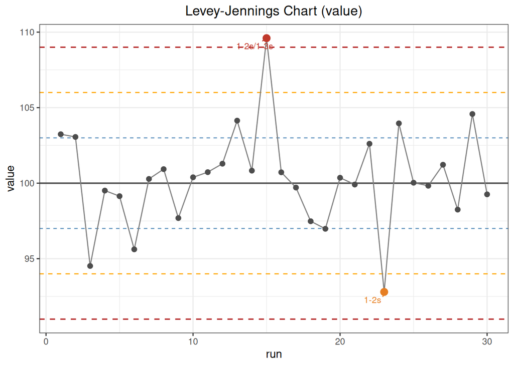

```r
plot(qc)
```

`qc_chart()` 把每条规则的违例点记录在 `$violations` 中：

```r
qc$violations
```

```
#> $`1-2s`
#> [1] 15 23
#>
#> $`1-3s`
#> [1] 15
#>
#> $`2-2s`
#> integer(0)
#>
#> $`R-4s`
#> integer(0)
#>
#> $`4-1s`
#> integer(0)
#>
#> $`10x`
#> integer(0)
```

本例第 15 点超出 +3s（触发 `1-3s` 与 `1-2s`，判为失控），第 23 点超出 −2s（触发 `1-2s`，判为 警告）。`n_warn` 与 `n_oc` 分别给出警告与失控点计数。

> **参数说明：** `qc_chart()` 的 `rules` 为逗号分隔的规则字符串；`mean`/`sd` 为目标值（不给出时用 数据估计，但监控质控应使用来自说明书的靶值）。`run` 指定运行顺序列，`group` 指定分组列（见示例二）。

# 4 示例二：试剂换批时的分组评价

## 4.1 读取数据

数据中前 10 个点为 L1 批、中间 10 个为 L2 批（存在整体偏移）、后 10 个为 L3 批：

```r
qc_lot <- read_csv("./data/qc-lot-change.csv", show_col_types = FALSE)
qc_lot <- as.data.frame(qc_lot)
table(qc_lot$lot)
```

```
#>
#> L1 L2 L3
#> 10 10 10
```

## 4.2 对整条序列分组

用 `group = "lot"` 画图，Westgard 规则仍在**整条序列**上判定：

```r
qc_lot_all <- qc_chart(
  qc_lot,
  value = "value",
  mean = 100,
  sd = 3,
  run = "run",
  group = "lot"
)
qc_lot_all$n_oc
```

```
#> [1] 0
```

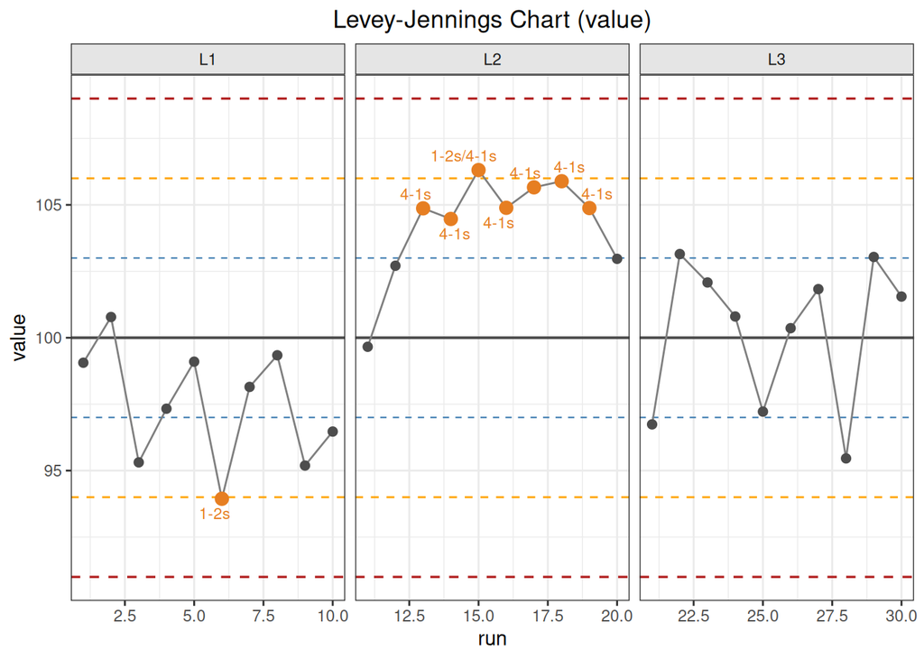

```r
plot(qc_lot_all)
```

图中虽按批分面，但规则在整条序列上计算，观察换批造成的系统性偏移。

# 5 示例三：双水平质控的 Youden 图

## 5.1 读取数据

Youden 图使用两个不同浓度（水平）的质控品在同一次运行中的结果（宽表格式，一列一个水平）：

```r
youden_dat <- read_csv("./data/qc-youden.csv", show_col_types = FALSE)
youden_dat <- as.data.frame(youden_dat)
head(youden_dat)
```

|  | run | low | high |
| --- | --- | --- | --- |
| 1 | 1 | 77.86 | 209.36 |
| 2 | 2 | 82.19 | 207.10 |
| 3 | 3 | 75.50 | 189.00 |
| 4 | 4 | 80.40 | 195.36 |
| 5 | 5 | 80.64 | 198.23 |
| 6 | 6 | 78.22 | 200.14 |

## 5.2 绘制 Youden 图

```r
yd <- youden_plot(
  youden_dat,
  sample1 = "low",
  sample2 = "high",
  mean1 = 80,
  mean2 = 200,
  sd1 = 2,
  sd2 = 5
)
print(yd)
```

```
#>
#> Youden Plot
#>   Sample 1 (low):
#>     Mean:   80.0000
#>     SD:     2.0000
#>   Sample 2 (high):
#>     Mean:   200.0000
#>     SD:     5.0000
#>   Correlation: 0.5428
#>   N (total):   30  |  Complete: 30  |  Missing: 0
#>   Points outside +/-2SD: 3  (rows: 3, 17, 19)
```

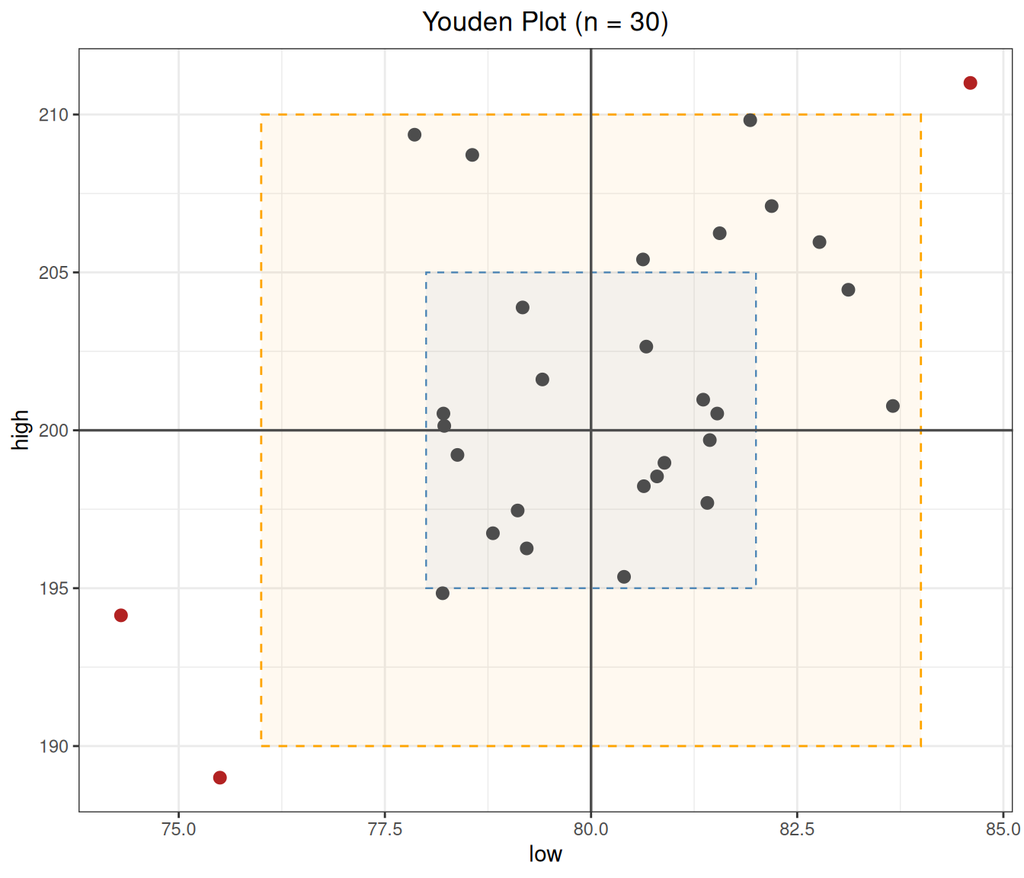

```r
plot(yd)
```

```r
yd$outside_rows
```

```
#> [1]  3 17 19
```

`youden_plot()` 用 ±2s 矩形框标注超出范围的点。本示例有 3 个运行点落在矩形外（含人为设置的 失控点），提示这些运行可能同时受到系统误差影响。两水平的共享偏移（点沿对角线方向外移）提示 系统误差，单一方向的大幅度偏移则更可能来自随机误差或单水平问题。

> **参数说明：** `youden_plot()` 的 `sample1`/`sample2` 为两个水平的数值列；`mean1`/`mean2`/ `sd1`/`sd2` 为靶值（不给出时用数据估计）。`$n_outside` 与 `$outside_rows` 给出矩形外的点。

# 6 结果判读要点

1. **靶值来源**：质控图的目标均值与 SD 应来自说明书或验证数据，而不是临时用数据估计。
2. **规则组合**：Westgard 规则组合与判为失控的处置流程应在方案中预先规定，并随风险重新评估。
3. **双水平互补**：Youden 图同时看两个水平的联合表现，识别系统误差与随机误差的迹象。
4. **失控处置**：检测到失控点后应停止报告、排查原因、必要时重新验证与召回，记录完整处置链。
5. **统计≠放行**：质控判定是放行决策的依据之一，最终决定应符合实验室质量体系要求。